# Final Project

Apollo Hodges

## Introduction

Pokemon Gen 8 Random Battles is a popular battle format on the Battle Simulation Website Pokemon Showdown! In this format, each player is given 6 random Pokemon, and the goal of the game is to use these Pokemon to knock out your opponents.

In this project, we’re going to be attempting to calculate what an individual Pokemon’s win rate is based on a few factors, namely its level, stats, and typing. This is useful, as Pokemon Showdown! is soon to add a bunch of new Pokemon in Gen 9 Random Battles, so we can actually use these predictions to predict win rates for those Pokemon too.

## Loading Packages and splitting data.

First, we’re going to clean and split our data into training and testing sets. Then we’ll use cross-fold validation to rotate training and testing data and validate our outcome.

```r
library(tidymodels)
library(ISLR)
library(ISLR2)
library(tidyverse)
library(glmnet)
library(janitor)
library(corrr)
library(rpart.plot)
library(vip)
library(randomForest)
library(ranger)
tidymodels_prefer()

set.seed(1008)

pokemon <- read.csv(file = 'ranbatsdata.csv')
Pokemon <- tibble(pokemon)
Pokemon_Cleaned <- clean_names(Pokemon)

df <- Pokemon_Cleaned$type2
df[df == '']<-'N/A'

Pokemon_Cleaned$type1 <- factor(Pokemon_Cleaned$type1)
Pokemon_Cleaned$type1 <- factor(Pokemon_Cleaned$type2)

Auto_split <- initial_split(Pokemon_Cleaned, strata = win_rate, prop = 0.7)
Auto_split
```

```
## <Training/Testing/Total>
## <308/132/440>
```

```r
Auto_train <- training(Auto_split)
Auto_test <- testing(Auto_split)

lm_spec <- linear_reg() %>%
  set_mode("regression") %>%
  set_engine("lm")

Auto_folds <- vfold_cv(Auto_train, v = 9)
Auto_folds
```

```
## #  9-fold cross-validation
## # A tibble: 9 × 2
##   splits           id
##   <list>           <chr>
## 1 <split [273/35]> Fold1
## 2 <split [273/35]> Fold2
## 3 <split [274/34]> Fold3
## 4 <split [274/34]> Fold4
## 5 <split [274/34]> Fold5
## 6 <split [274/34]> Fold6
## 7 <split [274/34]> Fold7
## 8 <split [274/34]> Fold8
## 9 <split [274/34]> Fold9
```

```r
pkmn_recipe <- recipe(win_rate ~  level+type1+type2+speed+attack+defense+sp_atk+sp_def+hp,
                      data = Auto_train) %>%
  step_dummy(all_nominal_predictors()) %>%
  step_normalize(all_numeric_predictors())
```

## Finding Correlation

Now that we have everything set up, let’s see if there’s any correlation between factors.

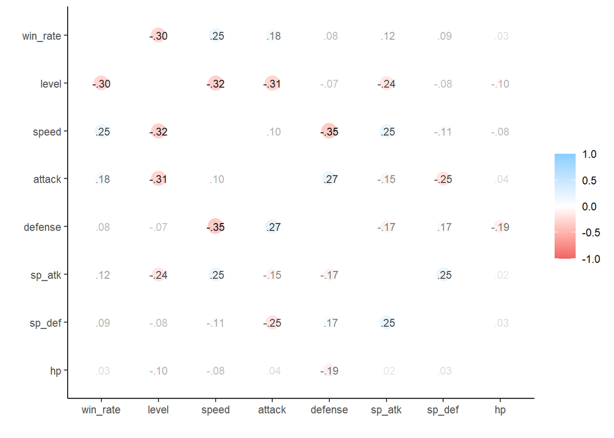

```r
cor_pkmn <- Auto_train %>%
  select(win_rate, level,type1,speed,attack,defense,sp_atk,sp_def,hp) %>%
  correlate()
rplot(cor_pkmn, print_cor=TRUE)
```

We can see that level has a negative correlation with most of the factors. This makes sense, as each Pokemon’s level is lowered or raised based on how strong or weak a Pokemon is. In terms of stats, speed has the highest correlation with win rate. Interestingly, attack has a higher correlation than Special Attack. I actually asked a highly rated player at this game about this beforehand, and she predicted this would be the case as well, explaining that attack is often more valuable than special attack.

## Linear Regression

Next, we’ll use Linear Regression and observe the results.

```r
pkmn_spec <- linear_reg(mixture = 0, penalty = 0) %>%
  set_mode("regression") %>%
  set_engine("glmnet")

pkmn_fit <- fit(pkmn_spec, win_rate ~ level+type1+type2+speed+attack+defense+sp_atk+sp_def+hp, data = Auto_train)

pkmn_workflow <- workflow() %>%
  add_recipe(pkmn_recipe) %>%
  add_model(pkmn_spec)

tidy(pkmn_fit)
```

```
## # A tibble: 44 × 3
##    term          estimate penalty
##    <chr>            <dbl>   <dbl>
##  1 (Intercept)    49.5          0
##  2 level          -0.0296       0
##  3 type1Bug       -0.236        0
##  4 type1Dark       0.179        0
##  5 type1Dragon    -0.124        0
##  6 type1Electric   0.269        0
##  7 type1Fairy     -0.0221       0
##  8 type1Fighting  -0.103        0
##  9 type1Fire      -0.481        0
## 10 type1Flying    -0.132        0
## # … with 34 more rows
```

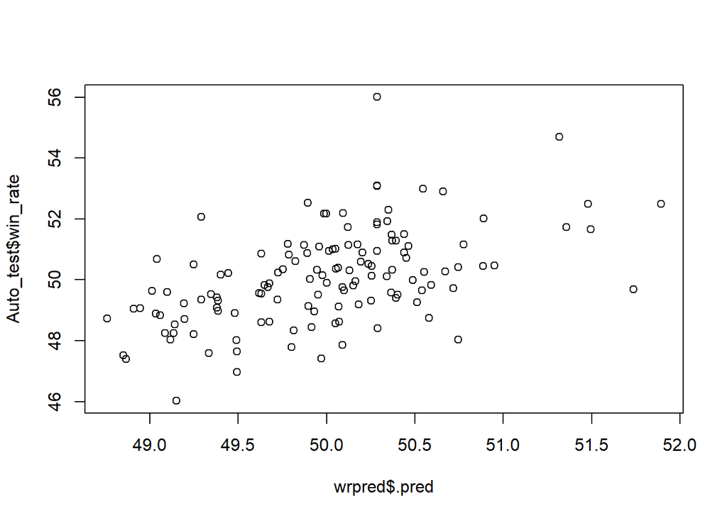

```r
wrpred <-predict(pkmn_fit, new_data = Auto_test)

plot(wrpred$.pred,Auto_test$win_rate)
```

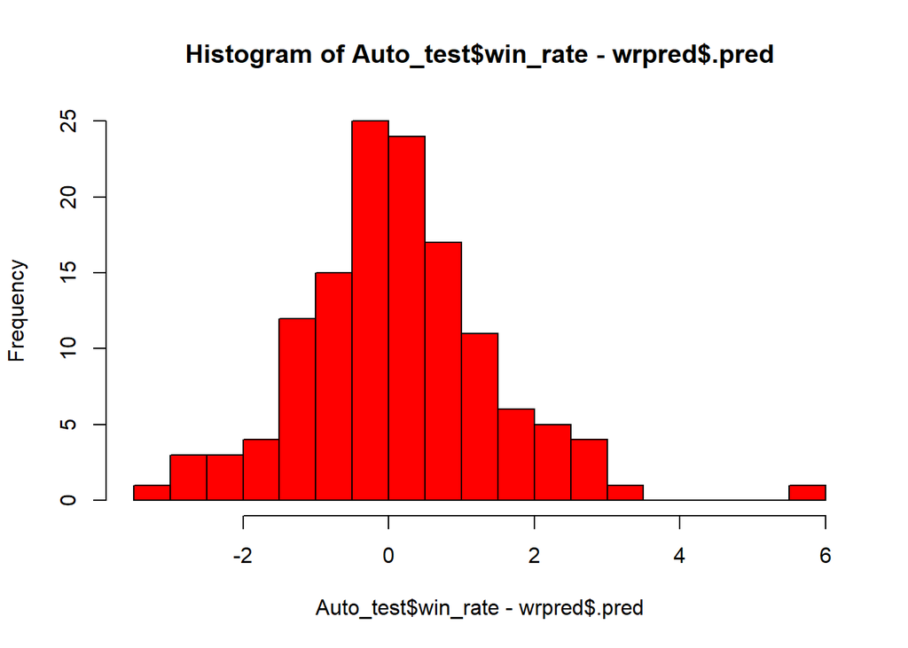

```r
hist(Auto_test$win_rate - wrpred$.pred, breaks=20, col="red")
```

The outlier here is actually from Silvally (Electric). The reason this is the case is because its win rate is a lot higher than one might expect, likely due to the low sample size of games it’s is in comparison to other Pokemon. While I could remove it, I thought it would be interesting to see if the model could predict it.

## Lasso Regression

Next up, lasso!

```r
lasso_spec <-
  linear_reg(penalty = tune(), mixture = 1) %>%
  set_mode("regression") %>%
  set_engine("glmnet")

lasso_workflow <- workflow() %>%
  add_recipe(pkmn_recipe) %>%
  add_model(lasso_spec)

penalty_grid <- grid_regular(penalty(range = c(-2, 2)), levels = 50)

tune_res <- tune_grid(
  lasso_workflow,
  resamples = Auto_folds,
  grid = penalty_grid
)

tune_res
```

```
## # Tuning results
## # 9-fold cross-validation
## # A tibble: 9 × 4
##   splits           id    .metrics           .notes
##   <list>           <chr> <list>             <list>
## 1 <split [273/35]> Fold1 <tibble [100 × 5]> <tibble [1 × 3]>
## 2 <split [273/35]> Fold2 <tibble [100 × 5]> <tibble [1 × 3]>
## 3 <split [274/34]> Fold3 <tibble [100 × 5]> <tibble [1 × 3]>
## 4 <split [274/34]> Fold4 <tibble [100 × 5]> <tibble [1 × 3]>
## 5 <split [274/34]> Fold5 <tibble [100 × 5]> <tibble [1 × 3]>
## 6 <split [274/34]> Fold6 <tibble [100 × 5]> <tibble [1 × 3]>
## 7 <split [274/34]> Fold7 <tibble [100 × 5]> <tibble [1 × 3]>
## 8 <split [274/34]> Fold8 <tibble [100 × 5]> <tibble [1 × 3]>
## 9 <split [274/34]> Fold9 <tibble [100 × 5]> <tibble [1 × 3]>
##
## There were issues with some computations:
##
##   - Warning(s) x9: A correlation computation is required, but `estimate` is constant...
##
## Run `show_notes(.Last.tune.result)` for more information.
```

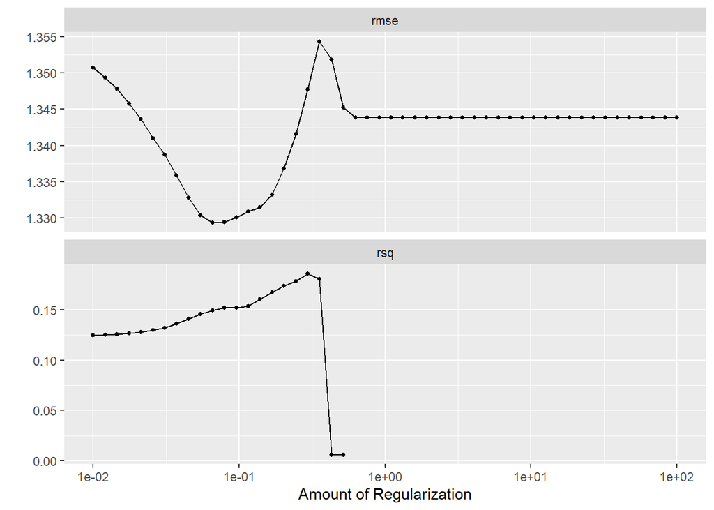

```r
autoplot(tune_res)
```

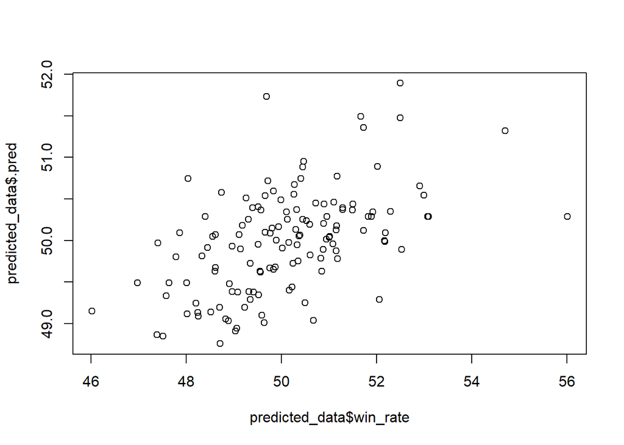

```r
best_model <- select_best(tune_res, metric = "rsq")

pkmn_final <- finalize_workflow(pkmn_workflow, best_model)

pkmn_final_fit <- fit(pkmn_final, data = Auto_train)

predicted_data <- augment(pkmn_final_fit, new_data = Auto_test) %>%
  select(win_rate, starts_with(".pred"))

plot(predicted_data$win_rate, predicted_data$.pred)
```

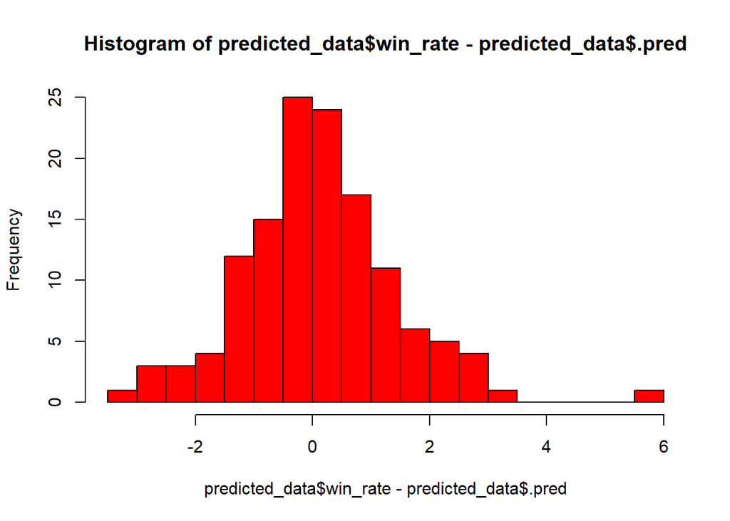

```r
hist(predicted_data$win_rate - predicted_data$.pred, breaks=20, col="red")
```

## Regression Tree

And finally, a regression tree.

```r
tree_spec <- decision_tree() %>%
  set_engine("rpart")

reg_tree_spec <- tree_spec %>%
  set_mode("regression")

reg_tree_fit <- fit(reg_tree_spec, win_rate ~ level+type1+type2+speed+attack+defense+sp_atk+sp_def+hp, Auto_train)
reg_tree_fit
```

```
## parsnip model object
##
## n= 308
##
## node), split, n, deviance, yval
##       * denotes terminal node
##
##   1) root 308 561.826200 49.99014
##     2) level>=80.5 216 389.474700 49.66212
##       4) level>=86.5 27  50.358040 48.51747
##         8) attack< 91 20  36.305720 48.24385 *
##         9) attack>=91 7   8.276813 49.29924 *
##       5) level< 86.5 189 298.686800 49.82564
##        10) speed< 75.5 100 122.803600 49.50758
##          20) speed>=46.5 66  66.744360 49.23442
##            40) type1=Flying,Ghost,Poison,Psychic 9   4.485586 48.46337 *
##            41) type1=,Bug,Dark,Dragon,Electric,Fairy,Fighting,Grass,Ice,Rock,Steel,Water 57  56.063270 49.35617
##              82) sp_atk< 57.5 14  12.805350 48.69709 *
##              83) sp_atk>=57.5 43  35.196680 49.57075
##               166) type1=,Bug,Dark,Electric,Grass,Ice,Rock 31  21.358950 49.33536 *
##               167) type1=Dragon,Fairy,Fighting,Steel,Water 12   7.682840 50.17883 *
##          21) speed< 46.5 34  41.575110 50.03783
##            42) type1=,Dragon,Electric,Ghost,Psychic,Steel 25  31.502490 49.76396
##              84) speed< 41.5 18  19.691250 49.43479 *
##              85) speed>=41.5 7   4.845425 50.61042 *
##            43) type1=Fairy,Ground,Poison,Rock,Water 9   2.989305 50.79855 *
##        11) speed>=75.5 89 154.400400 50.18301
##          22) level< 83.5 37  56.209230 49.82895
##            44) type1=Dragon,Fire,Flying,Normal 12  17.657120 49.03564 *
##            45) type1=,Dark,Electric,Fairy,Fighting,Grass,Steel,Water 25  27.375030 50.20974
##              90) attack>=97.5 13   8.937156 49.58575 *
##              91) attack< 97.5 12   7.892692 50.88572 *
##          23) level>=83.5 52  90.252480 50.43494
##            46) type1=,Fairy,Fighting,Ice,Normal,Poison,Psychic 43  64.819190 50.21587 *
##            47) type1=Dragon,Flying,Ghost,Grass,Ground 9  13.510000 51.48161 *
##     3) level< 80.5 92  94.544460 50.76027
##       6) type1=Bug,Dragon,Fighting,Fire,Flying,Grass,Ground,Ice,Poison,Steel,Water 51  39.128560 50.52401 *
##       7) type1=,Dark,Fairy,Ghost,Normal,Psychic 41  49.027820 51.05416
##        14) sp_def< 80.5 19  21.607770 50.58192 *
##        15) sp_def>=80.5 22  19.523410 51.46201 *
```

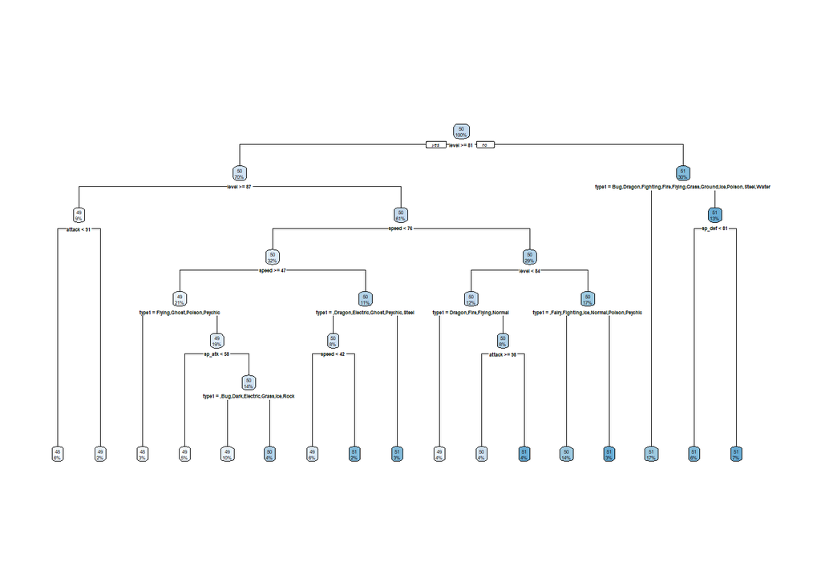

```r
reg_tree_fit %>%
  extract_fit_engine() %>%
  rpart.plot()
```

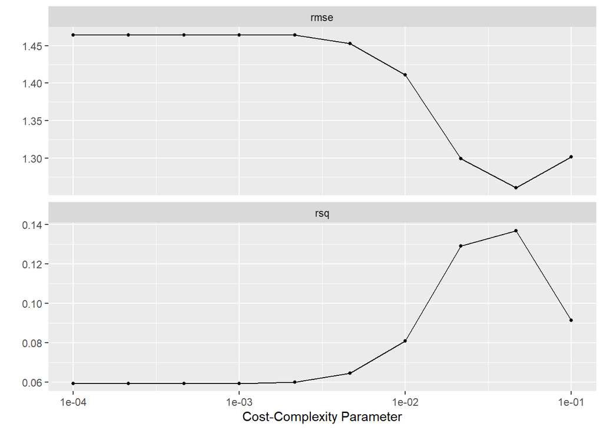

```r
reg_tree_wf <- workflow() %>%
  add_model(reg_tree_spec %>% set_args(cost_complexity = tune())) %>%
  add_formula(win_rate ~ level+type1+type2+speed+attack+defense+sp_atk+sp_def+hp)

param_grid <- grid_regular(cost_complexity(range = c(-4, -1)), levels = 10)

tune_res_tree <- tune_grid(
  reg_tree_wf,
  resamples = Auto_folds,
  grid = param_grid
)

autoplot(tune_res_tree)
```

```r
best_complexity <- select_best(tune_res_tree, metric = "rsq")

reg_tree_final <- finalize_workflow(reg_tree_wf, best_complexity)

reg_tree_final_fit <- fit(reg_tree_final, data = Auto_train)
reg_tree_final_fit
```

```
## ══ Workflow [trained] ══════════════════════════════════════════════════════════
## Preprocessor: Formula
## Model: decision_tree()
##
## ── Preprocessor ────────────────────────────────────────────────────────────────
## win_rate ~ level + type1 + type2 + speed + attack + defense +
##     sp_atk + sp_def + hp
##
## ── Model ───────────────────────────────────────────────────────────────────────
## n= 308
##
## node), split, n, deviance, yval
##       * denotes terminal node
##
## 1) root 308 561.82620 49.99014
##   2) level>=80.5 216 389.47470 49.66212
##     4) level>=86.5 27  50.35804 48.51747 *
##     5) level< 86.5 189 298.68680 49.82564 *
##   3) level< 80.5 92  94.54446 50.76027 *
```

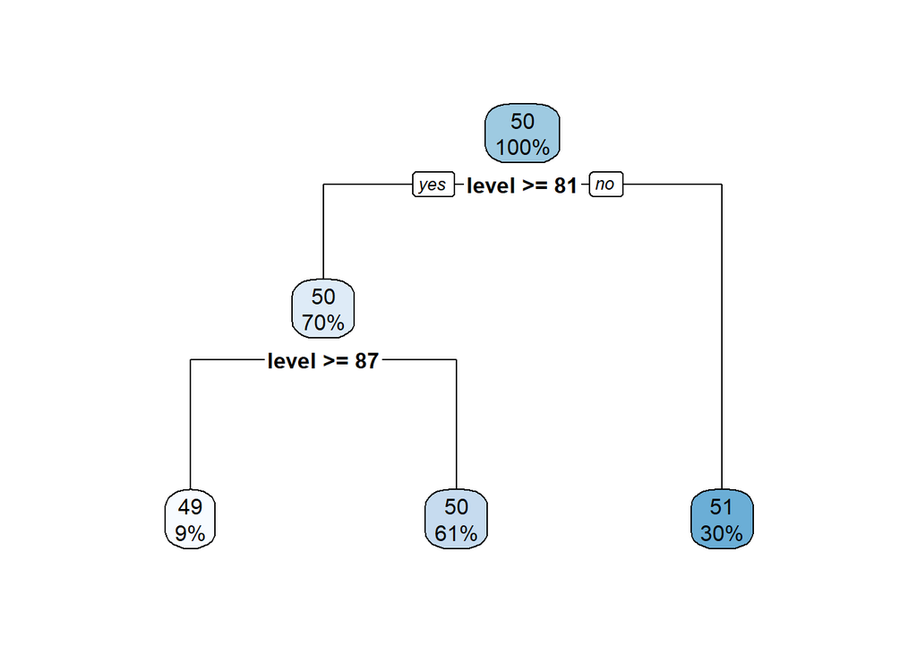

```r
reg_tree_final_fit %>%
  extract_fit_engine() %>%
  rpart.plot()
```

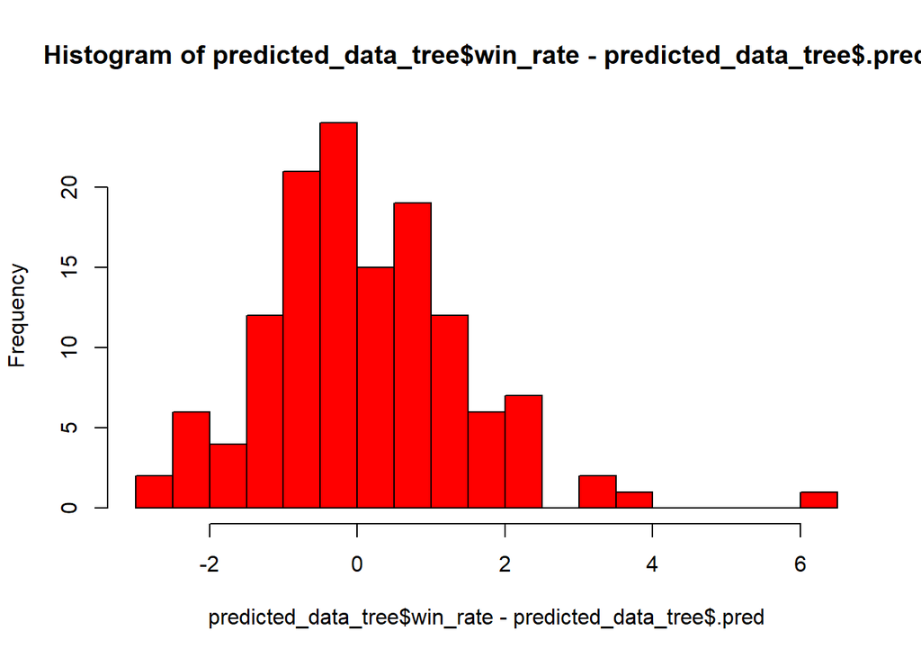

```r
predicted_data_tree <- augment(reg_tree_final_fit, new_data = Auto_test) %>%
  select(win_rate, starts_with(".pred"))

hist(predicted_data_tree$win_rate - predicted_data_tree$.pred, breaks=20, col="red")
```

We find that our Tree model is slightly worse at predicting win rates than our other two models.

In conclusion, these models aren’t actually great at prediction win rates. It’s possible that more factors, such as moves and items may help these models predict with more accuracy. However, as with the namesake, there is definately some randomness in it.

Another thing to note, I included both Zarude and Zarude-Dada as seperate entries despite sharing almost all factors. This is because they actually have significantly different win rates. This is an example of how win rates can be flawed in this random game.